# PROJECT - 7 Generating Continuous Random Variables

# NAME : Ruchin Patel

# USC ID: 9520665364

# Email : ruchinpa@usc.edu

# Problem Statement:

- Discuss that if Y is uniformly distributed over (0,1); then X = -ln(1-Y)  or X = -lnY  will be exponentially distributed with parameter $\lambda$ = 1 .
- Generate an erlang distribution using the above approach by generating sums of exponential variables.
- Do the same using a faster approach.
- Use rejection to generate a random variable which has the same or similir pdf to an erlang-3 distribution.
- Compare timings of all the methods.

# THEORETICAL EXPLORATION

- $\textbf{Exponential Distribution}$: An exponentially distributed RV is analogous to geometrically distributed DRV. Consider a time interval t = n$\delta$t, i.e. we discretize t into n small intervals and let the probability that an event occurs be given by: p = $\lambda \delta t$
  - Such sort of cases are modelled by exponential random variable.
  - CDF: $F_T(t) = 1 - e^{-\lambda t}$
  - PDF: $\lambda e^{-\lambda t}$
- $\textbf{Erlang Distribution}$: This distribution is the extension or a simple case of the gamma distribution. The erlang distribution is nothing but sum of n independent exponential distribution. When we use n exponential random variables, then such a random variable is known as Erlanf-n distribution.
  - CDF: $F_{S_n}(x)$ = 1 - $\sum_{j=0}^{n-1} \frac{{\lambda x}^j e^{-\lambda x}}{j!}$
  - pdf: $f_{S_n}(x)$ = $\frac{{\lambda x}^{n-1} \lambda e^{-\lambda x}}{(n-1)!}$
  - E[X] = $\frac{n}{\lambda}$. In our case n = 3 and $\lambda$ = 1 and hence E[X] = 3
  - ${\sigma}^2$ = $\frac{n}{{\lambda}^2}$. Again for erlang-3 distribution on our case ${\sigma}^2$ = 3
- $\textbf{Rejection Method}$: the rejection method is used to generate a random variable similar to a certain pdf using another efficient random variable.
  - The steps for the rejection method are mentioned in section 'e'.

## a.)

- If Y is uniformly distributed over (0,1); then X = -ln(1-Y) will be exponentially distributed with parameter $\lambda$. We will try to prove this in the following section.
  - It is to be noted that the exponential pdf is given by: $\lambda e^{-\lambda.x}$
  - Y ~ U(0,1) and (0 < y < 1)
  - Thus $f_{Y}(y)$ = 1 for (0 < y < 1)
  - X = -ln(1-Y)
    - Thus -X = ln(1-Y)
    - $e^{-X}$ = $e^{ln(1-Y)}$
    - $e^{-X}$ = 1 - Y
    - Y = 1 - $e^{-X}$ = $g^{-1}(X)$
    - Thus $\frac{dY}{dX}$ = 0 + $e^{-X}$
    - Thus $f_{X}(x)$ = $f_{X}(g^{-1}(X)) * |\frac{dY}{dX}|$
    - $f_{X}(x)$ = 1 * $e^{-X}$
    - Thus $f_{X}(x)$ = 1 *$e^{- 1*X}$
    - Comparing with the exponential pdf we can say that $f_{X}(x)$ = $\lambda e^{-\lambda.x}$ with $\lambda$ = 1
    - thus we proved that X = -ln(1-Y) with Y ~ U(0,1) is an exponential random variable with parameter $\lambda$ = 1
- If Y is uniformly distributed over (0,1); then X = -lnY will be exponentially distributed with parameter $\lambda$. We will try to prove this in the following section.
  - It is to be noted that the exponential pdf is given by: $\lambda e^{-\lambda.x}$
  - Y ~ U(0,1) and (0 < y < 1)
  - Thus $f_{Y}(y)$ = 1 for (0 < y < 1)
  - X = -ln(1-Y)
    - Thus -X = ln(Y)
    - $e^{-X}$ = $e^{ln(Y)}$
    - $e^{-X}$ = Y
    - Y = $e^{-X}$ = $g^{-1}(X)$
    - Thus $\frac{dY}{dX}$ = -$e^{-X}$
    - Thus $f_{X}(x)$ = $f_{X}(g^{-1}(X)) * |\frac{dY}{dX}|$
    - $f_{X}(x)$ = 1 * $e^{-X}$
    - Thus $f_{X}(x)$ = 1 *$e^{- 1*X}$
    - Comparing with the exponential pdf we can say that $f_{X}(x)$ = $\lambda e^{-\lambda.x}$ with $\lambda$ = 1
    - Thus we proved that X = -ln(Y) with Y ~ U(0,1) is also an exponential random variable with parameter $\lambda$ = 1

## b.)

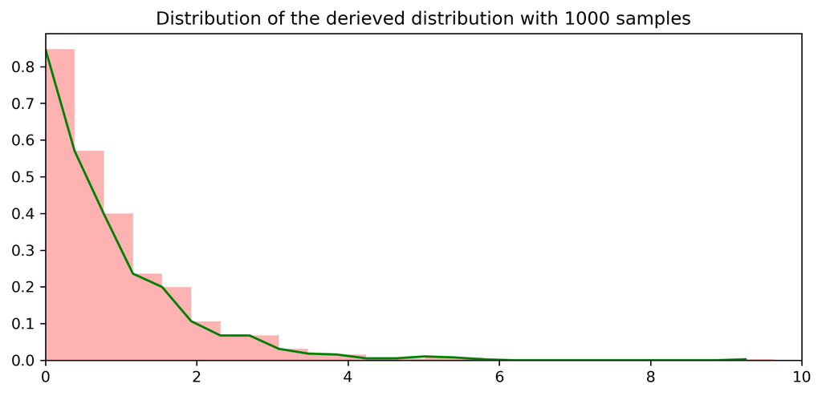

```python
X = generate_samples(1000)
s1 = 'Distribution of the derieved distribution with 1000 samples'
pdf = plot_distribution(X,25,'red','green',s1)
```

```python
def r():
    return generate_Erlang_c(3,1000)
```

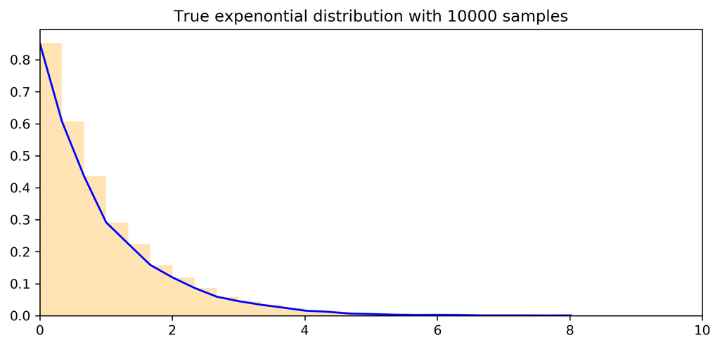

```python
exp = np.random.exponential(scale=1.0, size=10000)
s1 = 'True expenontial distribution with 10000 samples'
plot_distribution(exp,25,'orange','blue',s1)
```

## c.)

[figure not shown]

```
Sample mean:  3.0068620353587936
Sample variance:  3.0426630403653543
```

```python
erl = np.random.gamma(3,1,size=10000)
s1 = 'True erlang distribution with n=3 and sample size 1000'
plot_distribution(erl,25,'blue','red',s1)
print('Sample mean: ',np.mean(erl))
print('Sample variance: ',np.var(erl))
```

| Statistic | Theoretical |
| --- | --- |
| True Mean | 3.0 |
| True Variance | 3.0 |

- The above figure is the figure of a true erlang distribution with n = 3. Also shown are the mean and sample variance of the erlang distribution.
- As mentioned in the theoretical section the sample mean and sample variance are very close to the value 3 which are equal to the theoretical values.

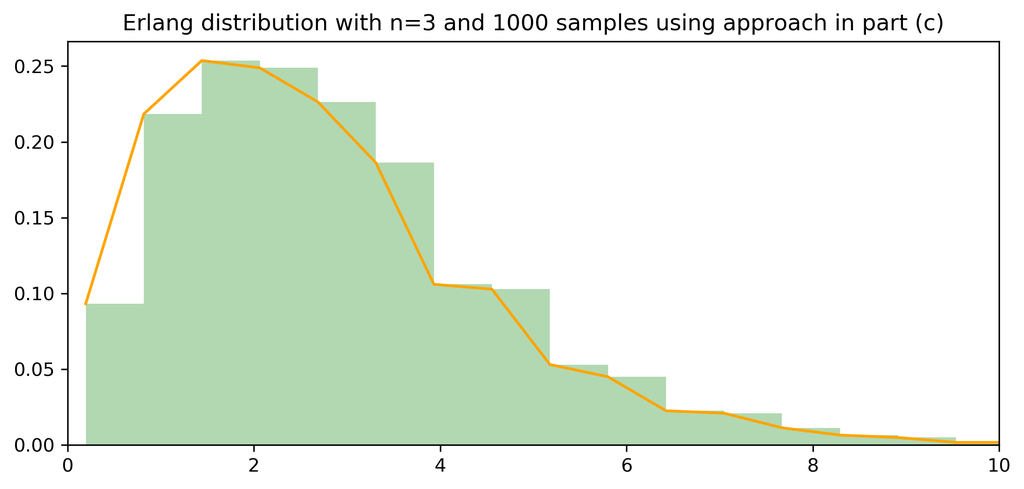

```
Sample mean:  2.9600271230485027
Sample variance:  3.101702115605387
```

```python
S_n = generate_Erlang_c(3,1000)
s1 = 'Erlang distribution with n=3 and 1000 samples using approach in part (c)'
plot_distribution(S_n[0],25,'green','orange',s1)
print('Sample mean: ',np.mean(S_n[0]))
print('Sample variance: ',np.var(S_n[0]))
```

- This is the Erlang distribution calculated by the formula mentioned above.
- As we can see the distribution is very similar to that of the true Erlang distribution.
- The mean and variance are also very close to the theoretical values And they are as follows:

| Statistic | Sample | Theoretical |
| --- | --- | --- |
| Mean | 2.96 | 3.0 |
| Variance | 3.101 | 3.0 |

## d.)

- Using a product and taking log of it gives us an erlang distribution because of the following reasons:
  - $S_n$ = -ln($\frac{\prod_{i=1}^{n} U_i}{\lambda}$) where [$\lambda$ = 1]
  - $S_n$ = -ln($\prod_{i=1}^{n} U_i$)
  - $S_n$ = $\sum_{i=1}^{n} -ln(U_i)$
  - Let $U_i$ = $Y_i$
  - Therefore, $S_n$ = $\sum_{i=1}^{n} -ln(Y_i)$
  - But from part a we know that if X = -ln(Y) with Y ~ U(0,1) then X is an ecponential variable.
  - Therefore, $S_n$ = $\sum_{i=1}^{n} X_i$, which is nothing but the same equation used in part (c).
  - Hence this approach should work

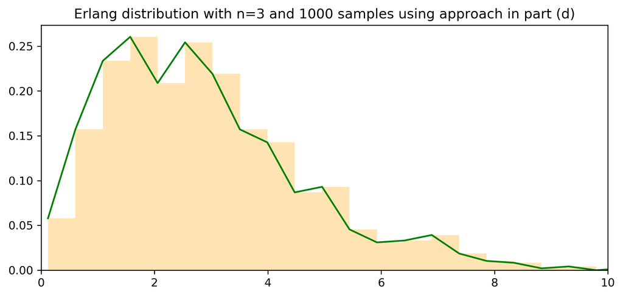

```
Sample mean:  3.040329017839072
Sample variance:  3.1060686081701587
```

```python
S_n = generate_Erlang_d(3,1000)
s1 = 'Erlang distribution with n=3 and 1000 samples using approach in part (d)'
plot_distribution(S_n[0],25,'orange','green',s1)
print('Sample mean: ',np.mean(S_n[0]))
print('Sample variance: ',np.var(S_n[0]))
```

| Statistic | Sample Stats[Part(c)] | Sample Stats[Part(d)] | Theoretical |
| --- | --- | --- | --- |
| Mean | 2.96 | 3.04 | 3.0 |
| Variance | 3.101 | 3.10 | 3.0 |

- $\textbf{Results}$: As seen from the above table, the results from methods in part c and part d are very similar to each other. This is because they both are doing the same thing only with a different approach and that different approach makes the algorithm in part (d) faster.

## e.)

- In order to create erlang distribution with n = 3 we first need to decide a probability distribution function that is like it and then scale it by a factor of c so that it bound the erlang-3 pdf function.
- To do this the following steps are taken.
  - $f_{S_n}$ = $\frac{(\lambda x)^{n-1} \lambda e^{-\lambda x}}{(n-1)!}$
  - In our case $\lambda = 1$ and n = 3
  - Thus, $f_{S_n}$ = $\frac{x^2 e^{-x}}{2}$
  - We select g(x) = ${\lambda}^{'} e^{{\lambda}^{'} x}$. Here we select ${\lambda}^{'}$ to be equal to the mean of the gamma function.
  - Thus g(x) = $\frac{1}{3} e^{\frac{-x}{3}}$
  - Thus, $\frac{f(x)}{g(x)}$ = $\frac{3}{2} x^2 e^{\frac{-2x}{3}}$
  - No in order to find x that maximizes the above equation we take its derivative and equate it to zero.
  - $\frac{d}{dx}[\frac{f(x)}{g(x)}]$ = 0
  - Thus, $2 x e^{\frac{-2x}{3}}[1 - \frac{x}{3}]$ = 0
  - Thus, x = 3
  - Thus c = $\frac{f(3)}{g(3)}$
  - Thus c = $\frac{3^3 e^{-2}}{2}$
  - Thus $\frac{f(x)}{cg(x)}$ = $\frac{x^2 e^{\frac{-2x}{3}}}{3^2 e^{-2}}$
- After calculating all this the algorithm works as follows:
  - Generate Y ~ exp(1/3)
  - R ~ U(0,1)
  - if R <= $\frac{f(y)}{cg(y)}$:
    - Accept X = Y
  - Else continue with the process.

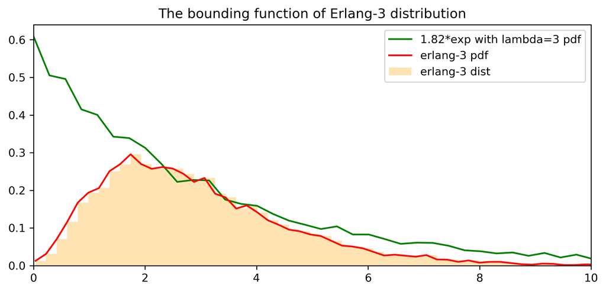

```python
exp_3 = np.random.exponential(scale=3, size=10000)
s1 = 'The bounding function of Erlang-3 distribution'
generate_bounding_func(erl,exp_3,85,'orange','green',s1)
```

```python
S_n_rej = rejection_method_erlang(1000)
```

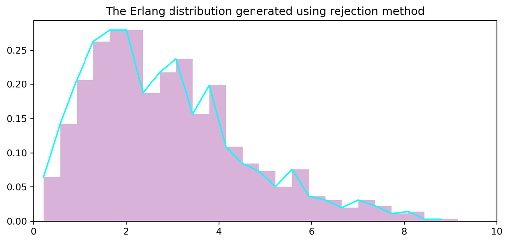

```
Sample Mean:  2.948029640278609
Sample Var:  2.779604810824049
```

```python
s1 = 'The Erlang distribution generated using rejection method'
plot_distribution(S_n_rej[0],25,'purple','cyan',s1)
print('Sample Mean: ',np.mean(S_n_rej[0]))
print('Sample Var: ',np.var(S_n_rej[0]))
```

[output not shown]

## e.)

```
Time taken by part c is:  14.203761100769043
```

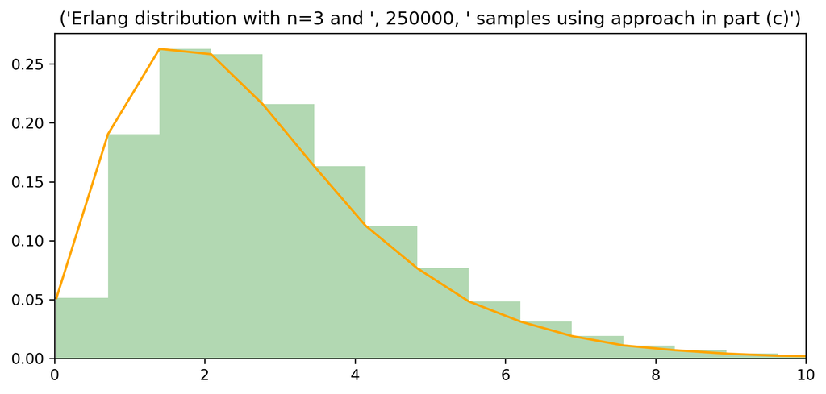

```
Sample Mean for part (c.):  2.997613511152498
Sample Var for part (c.):  2.99937472719769
Time taken by part d is:  10.4392671585083
```

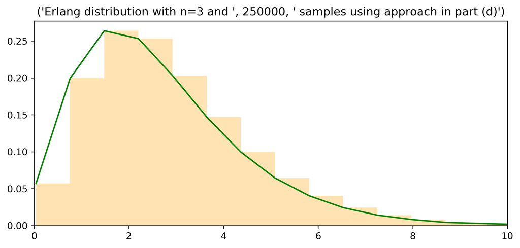

```
Sample Mean for part (d.):  2.9995716808968074
Sample Var for part (d.):  2.9767343394223227
Time taken by part d is:  34.6606559753418
```

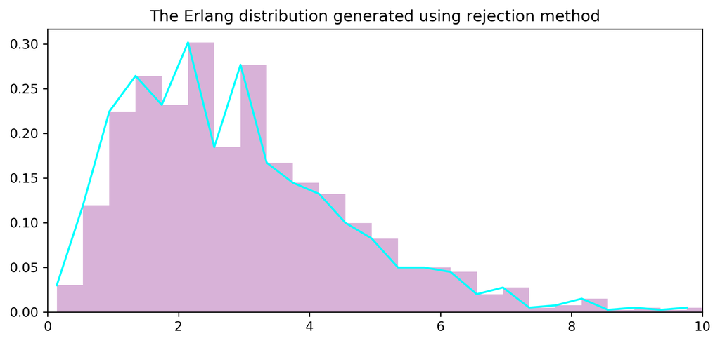

```
Sample Mean: for part (e.):  3.0092366924203406
Sample Var: for part (e.):   2.8278709480877864
```

```python
calculate_time(250000)
```

[output not shown]

# Function Definition

```python
import numpy as np
import sklearn as sk
import scipy.stats as sci
import matplotlib.pyplot as plt
from matplotlib.font_manager import FontProperties
import matplotlib.mlab as mlab
import seaborn as sns
import warnings
import scipy.stats as st
import operator
from scipy.stats import binom
from scipy.stats import geom
warnings.filterwarnings('ignore')
%matplotlib inline
fontP = FontProperties()
fontP.set_size('small')
np.random.RandomState(seed=42)
from time import time



def generate_samples(n):

    #np.random.RandomState(seed=42)
    Y = np.array(np.random.uniform(0,1,n))
    X = -1*np.log(Y)
    return X

def plot_distribution(X,b,hist_col,kde_col,s):

    plt.figure(figsize=(9,4), dpi=300)
    orig_pdf,bins,patches = plt.hist(X,bins=b,normed = True, \
                                       color=hist_col,alpha = 0.3 \
                                    )

    plt.plot(bins[0:len(bins)-1],orig_pdf,color = kde_col)
    plt.xlim(0,10)
    plt.title(s)
    plt.show()


def generate_Erlang_c(n,m):

    S_n = []
    start = time() # Get start time
    for i in range(0,m):
        X_n = []
        for j in range(0,n):
            Y = np.array(np.random.uniform(0,1,1))
            X = -1*np.log(Y)
            X_n.append(X)

        S_i = np.sum(X_n)
        S_n.append(S_i)
    end = time() # Get start time
    tot = end - start

    return np.array(S_n),tot



def generate_Erlang_d(n,m):

    S_n = []
    start = time() # Get start time
    for i in range(0,m):
        U = []
        for j in range(0,n):
             U.append(np.random.uniform(0,1,1))

        S_i = -1 * np.log(np.prod(U))
        S_n.append(S_i)

    end = time() # Get start time
    tot = end - start

    return np.array(S_n),tot


def generate_bounding_func(erl,exp,b,hist_col,kde_col,s):

    plt.figure(figsize=(9,4), dpi=300)


    exp_pdf,bins_exp,patches = plt.hist(exp,bins=b,normed = True, \
                                       color='green',alpha = 0 \
                                       )

    erl_pdf,bins_erl,patches = plt.hist(erl,bins=b,normed = True, \
                                       color=hist_col,alpha = 0.3 \
                                       ,label = 'erlang-3 dist')



    exp_pdf = exp_pdf*1.82
    plt.plot(bins_exp[0:len(bins_exp)-1],exp_pdf,color = kde_col,label='1.82*exp with lambda=3 pdf')
    plt.plot(bins_erl[0:len(bins_exp)-1],erl_pdf,color = 'red',label='erlang-3 pdf')
    plt.xlim(0,10)
    plt.title(s)
    plt.legend()
    plt.show()

def rejection_method_erlang(n):

    S_n = []
    p = 0

    start = time() # Get start time
    while(p < n):

        X = np.random.exponential(scale=1/3, size=1)
        R = np.random.uniform(0,1,size=1)

        den = 3*3*np.exp(-2)
        num = X*X*np.exp(X*(2/3))
        #den = (3**4)*(np.exp(-2))
        #num = X*X*np.exp(2*X)

        if(R <= (num/den)):
            S_n.append(X[0])
            p += 1
    end = time() # Get end time
    tot = end-start

    S_n = r()[0]

    return S_n,tot

def calculate_time(N):

    S_n = generate_Erlang_c(3,N)
    print('Time taken by part c is: ',S_n[1])
    s1 = 'Erlang distribution with n=3 and ',N,' samples using approach in part (c)'
    plot_distribution(S_n[0],25,'green','orange',s1)
    print('Sample Mean for part (c.): ',np.mean(S_n[0]))
    print('Sample Var for part (c.): ',np.var(S_n[0]))

    S_n = generate_Erlang_d(3,N)
    print('Time taken by part d is: ',S_n[1])
    s1 = 'Erlang distribution with n=3 and ',N,' samples using approach in part (d)'
    plot_distribution(S_n[0],25,'orange','green',s1)
    print('Sample Mean for part (d.): ',np.mean(S_n[0]))
    print('Sample Var for part (d.): ',np.var(S_n[0]))

    S_n_rej = rejection_method_erlang(N)
    print('Time taken by part d is: ',S_n_rej[1])
    s1 = 'The Erlang distribution generated using rejection method'
    plot_distribution(S_n_rej[0],25,'purple','cyan',s1)
    print('Sample Mean: for part (e.): ',np.mean(S_n_rej[0]))
    print('Sample Var: for part (e.):  ',np.var(S_n_rej[0]))
```